# Query openrouteservice from R

Andrzej Oleś

2025-02-08

## Get started

*openrouteservice* R package provides easy access to the [openrouteservice](https://openrouteservice.org) (ORS) API from R. It allows you to painlessly consume the following services:

- [directions](https://openrouteservice.org/dev/#/api-docs/v2/directions/%7Bprofile%7D/post) (routing)
- [geocoding](https://openrouteservice.org/dev/#/api-docs/geocode) powered by [Pelias](https://pelias.io)
- [isochrones](https://openrouteservice.org/dev/#/api-docs/v2/isochrones/%7Bprofile%7D/post) (accessibility)
- time-distance [matrices](https://openrouteservice.org/dev/#/api-docs/v2/matrix/%7Bprofile%7D/post)
- [snapping](https://openrouteservice.org/dev/#/api-docs/v2/snap/%7Bprofile%7D/post) to OpenStreetMap ways
- [exporting](https://openrouteservice.org/dev/#/api-docs/v2/export/%7Bprofile%7D/post) the underlying routing graph structure
- [pois](https://openrouteservice.org/dev/#/api-docs/pois/post) (points of interest)
- SRTM elevation for point and lines geometries
- routing [optimization](https://openrouteservice.org/dev/#/api-docs/optimization/post) based on [Vroom](http://vroom-project.org/)

### Disclaimer

By using this package, you agree to the ORS [terms and conditions](https://openrouteservice.org/terms-of-service/).

### Installation

The latest release version can be readily obtained from CRAN via a call to

```r
install.packages("openrouteservice")
```

For running the current development version from GitHub it is recommended to use pak, as it handles the installation of all the necessary packages and their system dependencies automatically.

```r
# install.packages("pak")
pak::pak("GIScience/openrouteservice-r")
```

### Setting up API key

In order to start using ORS services you first need to set up your personal API key, which you can [get for free](https://openrouteservice.org/dev/#/signup). Once you are signed up, go to https://openrouteservice.org/dev/#/home -> `TOKENS`. At the bottom of the page you can request a free token (name can be anything).

```r
library(openrouteservice)

ors_api_key("<your-api-key>")
```

This will save the key in the default keyring of your system credential store. Once the key is defined, it persists in the keyring store of the operating system. This means that it survives beyond the termination of the R session, so you don’t need to set it again each time you start a new R session. To retrieve the key just call `ors_api_key()` without the `key` argument.

Alternatively, they key can be provided in the environment variable `ORS_API_KEY`. The value from the environment variable takes precedence over the former approach allowing to bypass the keyring infrastructure.

## Directions

`ors_directions()` interfaces the ORS directions service to compute routes between given `coordinates`.

```r
library(openrouteservice)

coordinates <- list(c(8.34234, 48.23424), c(8.34423, 48.26424))

x <- ors_directions(coordinates)
```

Way points can be provided as a list of coordinate pairs `c(lon, lat)`, or a 2-column matrix-like object such as a data frame.

```r
coordinates <- data.frame(lon = c(8.34234, 8.34423), lat = c(48.23424, 48.26424))
```

The response formatting defaults to geoJSON which allows to easily [visualize](https://rstudio.github.io/leaflet/json.html#working-with-raw-geojsontopojson) it with e.g. leaflet.

```r
library(leaflet)

leaflet() %>%
  addTiles() %>%
  addGeoJSON(x, fill=FALSE) %>%
  fitBBox(x$bbox)
```

[interactive chart not shown]

Other output formats, such as GPX, can be specified in the argument `format`. Note that plain JSON response returns the geometry as [Google’s encoded polyline](https://developers.google.com/maps/documentation/utilities/polylinealgorithm),

```r
x <- ors_directions(coordinates, format = "json")

geometry <- x$routes[[1]]$geometry
str(geometry)
```

```
##  chr "mtkeHuv|q@~@VhAf@PR|@hBt@j@^n@L\\NjAX`BNXqAlFM^kArAoAfBs@^WFY?{Be@[?WJWRi@t@Q^]`AQRULoAPWHOL]h@mA`C_@d@oAdAkCrB"| __truncated__
```

so an additional postprocessing step might be necessary.

```r
library(googlePolylines)
str(decode(geometry))
```

```
## List of 1
##  $ :'data.frame':    166 obs. of  2 variables:
##   ..$ lat: num [1:166] 48.2 48.2 48.2 48.2 48.2 ...
##   ..$ lon: num [1:166] 8.34 8.34 8.34 8.34 8.34 ...
```

The API offers a wide range of `profile`s for multiple modes of transport, such as: car, heavy vehicle, different bicycle types, walking, hiking and wheelchair. These can be listed with

```r
ors_profile()
```

```
##                car                hgv               bike           roadbike                mtb
##      "driving-car"      "driving-hgv"  "cycling-regular"     "cycling-road" "cycling-mountain"
##             e-bike            walking             hiking         wheelchair
## "cycling-electric"     "foot-walking"      "foot-hiking"       "wheelchair"
```

Each of these modes uses a carefully compiled street network to suite the profiles requirements.

```r
x <- ors_directions(coordinates, profile="cycling-mountain")

leaflet() %>%
  addTiles() %>%
  addGeoJSON(x, fill=FALSE) %>%
  fitBBox(x$bbox)
```

[interactive chart not shown]

Any optional [query parameters](https://openrouteservice.org/dev/#/api-docs/v2/directions/%7Bprofile%7D/post) can be specified by providing them as additional `...` arguments to `ors_directions`. For example, in order to plot the elevation profile of a route colored by steepness use `elevation = TRUE` to add height to the coordinates of the points along the route and query for steepness in `extra_info`.

```r
library("sf")
x <- ors_directions(coordinates, profile = "cycling-mountain", elevation = TRUE,
                    extra_info = "steepness", output = "sf")

height <- st_geometry(x)[[1]][, 3]
```

Here we use [simple features](https://CRAN.R-project.org/package=sf) output for the sake of easy postprocessing which includes finding the length of individual route segments and their distance relative to the starting point. These can be computed with `st_distance()` upon converting the `LINESTRING` to a list of `POINT`s,

```r
points <- st_cast(st_geometry(x), "POINT")
n <- length(points)
segments <- cumsum(st_distance(points[-n], points[-1], by_element = TRUE))
```

```
## st_as_s2(): dropping Z and/or M coordinate
## st_as_s2(): dropping Z and/or M coordinate
```

while their steepness can be extracted from the requested metadata.

```r
steepness <- x$extras$steepness$values
steepness <- rep(steepness[,3], steepness[,2]-steepness[,1])
steepness <- factor(steepness, -5:5)

palette = setNames(rev(RColorBrewer::brewer.pal(11, "RdYlBu")), levels(steepness))
```

For the final plot we use ggplot2 in combinations with units which supports handling of length units associated with the data.

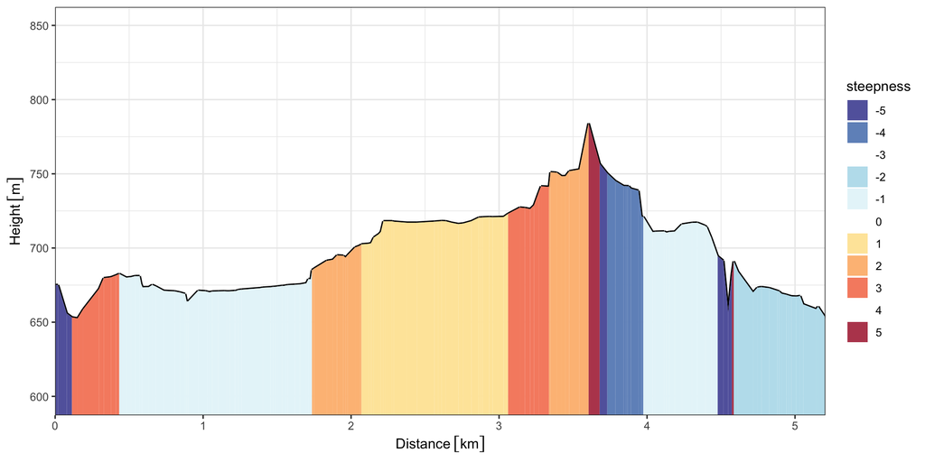

```r
library("ggplot2")
#library("ggforce")
library("units")

units(height) <- as_units("m")

df <- data.frame(x1 = c(set_units(0, "m"), segments[-(n-1)]),
                 x2 = segments,
                 y1 = height[-n],
                 y2 = height[-1],
                 steepness)

y_ran = range(height) * c(0.9, 1.1)

n = n-1

df2 = data.frame(x = c(df$x1, df$x2, df$x2, df$x1),
                 y = c(rep(y_ran[1], 2*n), df$y2, df$y1),
                 steepness,
                 id = 1:n)

ggplot() + theme_bw() +
  geom_segment(data = df, aes(x1, y1, xend = x2, yend = y2), linewidth = 1) +
  geom_polygon(data = df2, aes(x, y, group = id), fill = "white") +
  geom_polygon(data = df2, aes(x, y , group = id, fill = steepness)) +
  scale_fill_manual(values = alpha(palette, 0.8), drop = FALSE) +
  scale_x_units(unit = "km", expand = c(0,0)) +
  scale_y_units(expand = c(0,0), limits = y_ran) +
  labs(x = "Distance", y = "Height")
```

Advanced `options` are natively formatted as JSON objects, but can be passed as their R list representation.

```r
polygon = list(
    type = "Polygon",
    coordinates = list(
      list(
        c(8.330469, 48.261570),
        c(8.339052, 48.261570),
        c(8.339052, 48.258227),
        c(8.330469, 48.258227),
        c(8.330469, 48.261570)
      )
    ),
    properties = ""
  )

options <- list(
  avoid_polygons = polygon
)

x <- ors_directions(coordinates, profile="cycling-mountain", options=options)

leaflet() %>%
  addTiles() %>%
  addGeoJSON(polygon, color="#F00") %>%
  addGeoJSON(x, fill=FALSE) %>%
  fitBBox(x$bbox)
```

[interactive chart not shown]

## Isochrones

Reachability has become a crucial component for many businesses from all different kinds of domains. `ors_isochrones()` helps you to determine which areas can be reached from certain location(s) in a given time or travel distance. The reachability areas are returned as contours of polygons. Next to the `range` provided in seconds or meters you may as well specify the corresponding `interval`s. The list of optional arguments to `ors_isochrones()` is similar as to `ors_directions()`.

```r
library(mapview)

# embed data in the output file
mapviewOptions(fgb = FALSE)

coordinates <- data.frame(lon = c(8.34234, 8.34234), lat = c(48.23424, 49.23424))

## 30 minutes range split into 10 minute intervals
res <- ors_isochrones(coordinates, range = 1800, interval = 600, output = "sf")
res
```

```
## Simple feature collection with 6 features and 3 fields
## Geometry type: POLYGON
## Dimension:     XY
## Bounding box:  xmin: 8.037287 ymin: 48.08962 xmax: 8.851253 ymax: 49.60432
## Geodetic CRS:  WGS 84
##   group_index value              center                       geometry
## 1           0   600 8.344268, 48.233826 POLYGON ((8.26521 48.22288,...
## 2           0  1200 8.344268, 48.233826 POLYGON ((8.213659 48.27965...
## 3           0  1800 8.344268, 48.233826 POLYGON ((8.142075 48.28162...
## 4           1   600 8.343705, 49.234211 POLYGON ((8.277124 49.25627...
## 5           1  1200 8.343705, 49.234211 POLYGON ((8.14161 49.26321,...
## 6           1  1800 8.343705, 49.234211 POLYGON ((8.037461 49.26759...
```

```r
values <- levels(factor(res$value))
ranges <- split(res, values)
ranges <- ranges[rev(values)]

names(ranges) <- sprintf("%s min", as.numeric(names(ranges))/60)

mapview(ranges, alpha.regions = 0.2, homebutton = FALSE, legend = FALSE)
```

[interactive chart not shown]

Here we have used `sf` output for the sake of some further postprocessing and visualization. By grouping the isochrones according to ranges we gain the ability of toggling individual ranges when displayed in mapview. Another option could be to group by locations. The following example illustrates a possible approach to applying a custom color palette to the non-overlapping parts of isochrones.

```r
locations = split(res, res$group_index)

locations <- lapply(locations, function(loc) {
  g <- st_geometry(loc)
  g[-which.min(values)] <- st_sfc(Map(st_difference,
                                      g[match(values[-which.min(values)], loc$value)],
                                      g[match(values[-which.max(values)], loc$value)]))
  st_geometry(loc) <- g
  loc
})

isochrones <- unsplit(locations, res$group_index)

pal <- setNames(heat.colors(length(values)), values)
mapview(isochrones, zcol = "value", col = pal, col.regions = pal,
        alpha.regions = 0.5, homebutton = FALSE)
```

[interactive chart not shown]

## Matrix

One to many, many to many or many to one: `ors_matrix()` allows you to obtain aggregated time and distance information between a set of locations (origins and destinations). Unlike `ors_directions()` it does not return detailed route information. But you may still specify the transportation mode and compute routes which adhere to certain restrictions, such as avoiding specific road types or object characteristics.

```r
coordinates <- list(
  c(9.970093, 48.477473),
  c(9.207916, 49.153868),
  c(37.573242, 55.801281),
  c(115.663757,38.106467)
)

# query for duration and distance in km
res <- ors_matrix(coordinates, metrics = c("duration", "distance"), units = "km")

# duration in hours
(res$durations / 3600) %>% round(1)
```

```
##       [,1]  [,2] [,3]  [,4]
## [1,]   0.0   1.6 25.2 108.8
## [2,]   1.6   0.0 25.1 108.7
## [3,]  25.2  25.1  0.0  84.1
## [4,] 108.8 108.7 84.0   0.0
```

```r
# distance in km
res$distances %>% round
```

```
##      [,1] [,2] [,3] [,4]
## [1,]    0  154 2414 9776
## [2,]  154    0 2388 9750
## [3,] 2363 2338    0 7324
## [4,] 9711 9687 7309    0
```

## Geocoding

`ors_geocode()` transforms a description of a location provided in `query`, such as the place’s name, street address or postal code, into a normalized description of the location with a point geometry. Additionally, it offers reverse geocoding which does exactly the opposite: It returns the next enclosing object which surrounds the coordinates of the given `location`. To obtain more relevant results you may also set a radius of tolerance around the requested coordinates.

```r
## locations of Heidelberg around the globe
x <- ors_geocode("Heidelberg")

leaflet() %>%
  addTiles() %>%
  addGeoJSON(x) %>%
  fitBBox(x$bbox)
```

[interactive chart not shown]

```r
## set the number of results returned
x <- ors_geocode("Heidelberg", size = 1)

## search within a particular country
x <- ors_geocode("Heidelberg", boundary.country = "DE")

## structured geocoding
x <- ors_geocode(list(locality="Heidelberg", county="Heidelberg"))

## reverse geocoding
location <- x$features[[1L]]$geometry$coordinates

y <- ors_geocode(location = location, layers = "locality", size = 1)
```

## POIs

This service allows you to find places of interest around or within given geographic coordinates. You may search for given features around a point, path or even within a polygon specified in `geometry`. To list all the available POI categories use `ors_pois('list')`.

```r
geometry <- list(
  geojson = list(
    type = "Point",
    coordinates = c(8.8034, 53.0756)
  ),
  buffer = 500
)

ors_pois(
  request = 'pois',
  geometry = geometry,
  limit = 2000,
  sortby = "distance",
  filters = list(
    category_ids = 488,
    wheelchair = "yes"
  ),
  output = "sf"
)
```

```
## Simple feature collection with 3 features and 5 fields
## Geometry type: POINT
## Dimension:     XY
## Bounding box:  xmin: 8.80294 ymin: 53.07452 xmax: 8.80903 ymax: 53.0757
## Geodetic CRS:  WGS 84
##   category_ids  distance osm_tags osm_type     osm_id                 geometry
## 1 kiosk, shops  32.95127      yes        1  726580652  POINT (8.80294 53.0757)
## 2 kiosk, shops 292.89365      yes        1 2525463951 POINT (8.80777 53.07559)
## 3 kiosk, shops 395.87884      yes        1 4827632819 POINT (8.80903 53.07452)
```

You can gather statistics on the amount of certain POIs in an area by using `request='stats'`.

```r
ors_pois(
  request = 'stats',
  geometry = geometry,
  limit = 2000,
  sortby = "distance",
  filters = list(category_ids = 488)
  )
```

```
## <ors_pois>
## List of 2
##  $ places     :List of 2
##   ..$ total_count: int 8
##   ..$ shops      :List of 3
##   .. ..$ group_id   : int 420
##   .. ..$ categories :List of 1
##   .. .. ..$ kiosk:List of 2
##   .. .. .. ..$ count      : int 8
##   .. .. .. ..$ category_id: int 488
##   .. ..$ total_count: int 8
##  $ information:List of 4
##   ..$ attribution: chr "openrouteservice.org | OpenStreetMap contributors"
##   ..$ version    : chr "0.1"
##   ..$ timestamp  : int 1738974985
##   ..$ query      :List of 5
##   .. ..$ request : chr "stats"
##   .. ..$ limit   : int 2000
##   .. ..$ sortby  : chr "distance"
##   .. ..$ filters :List of 1
##   .. .. ..$ category_ids: int 488
##   .. ..$ geometry:List of 2
##   .. .. ..$ geojson:List of 2
##   .. .. .. ..$ type       : chr "Point"
##   .. .. .. ..$ coordinates: num [1:2] 8.8 53.1
##   .. .. ..$ buffer : int 500
```

## Elevation

Given a point or line geometry you can use `ors_elevation` to query for its elevation.

```r
x <- ors_geocode("Königstuhl", output = "sf")

ors_elevation("point", st_coordinates(x))
```

```
## <ors_elevation>
##  num [1:3] 8.72 49.4 560
```

## Optimization

The optimization endpoint solves the [vehicle routing problem](https://en.wikipedia.org/wiki/Vehicle_routing_problem) (VRP) of finding an optimal set of routes for a fleet of vehicles to traverse in order to deliver to a given set of locations. The service is based on [Vroom](https://github.com/VROOM-Project/vroom) and can be used to schedule multiple vehicles and jobs respecting time windows, capacities and required skills. VRP generalizes the classic [traveling salesman problem](https://en.wikipedia.org/wiki/Travelling_salesman_problem) of finding the fastest or shortest possible route that visits a given list of locations.

The following example involves a 2-vehicle fleet carrying out deliveries across 6 locations.

```r
home_base <- data.frame(lon = 2.370658, lat = 48.721666)

vehicles = vehicles(
  id = 1:2,
  profile = "driving-car",
  start = home_base,
  end = home_base,
  capacity = 4,
  skills = list(c(1, 14), c(2, 14)),
  time_window = c(28800, 43200)
)
```

Both `vehicles` share the `start`/`end` points and have the same `capacity`, but differ in the set of `skills` assigned. We are interested in using them to serve a number of `jobs` with certain `skills` requirements between `locations`. These skills are mandatory, which means a given job can only be served by a vehicle that has all its required skills.

```r
locations <- list(
  c(1.98806, 48.705),
  c(2.03655, 48.61128),
  c(2.39719, 49.07611),
  c(2.41808, 49.22619),
  c(2.28325, 48.5958),
  c(2.89357, 48.90736)
)

jobs = jobs(
  id = 1:6,
  service = 300,
  amount = 1,
  location = locations,
  skills = list(1, 1, 2, 2, 14, 14)
)
```

The helper functions `vehicles` and `jobs` produce `data.frame`s which have the format appropriate for `ors_optimization`. Route geometries are enabled by setting the corresponding flag in `options`.

```r
res <- ors_optimization(jobs, vehicles, options = list(g = TRUE))
```

The geometries are returned as [Google’s encoded polylines](https://developers.google.com/maps/documentation/utilities/polylinealgorithm), so for visualization in leaflet they need to be decoded. Furthermore, we extract the job locations from the response such that we can label them in the order in which they are visited along the routes.

```r
lapply(res$routes, with, {
  list(
    geometry = googlePolylines::decode(geometry)[[1L]],
    locations = lapply(steps, with, if (type=="job") location) %>%
      do.call(rbind, .) %>% data.frame %>% setNames(c("lon", "lat"))
  )
  }) -> routes

## Helper function to add a list of routes and their ordered waypoints
addRoutes <- function(map, routes, colors) {
  routes <- mapply(c, routes, color = colors, SIMPLIFY = FALSE)
  f <- function (map, route) {
    with(route, {
      labels <- sprintf("<b>%s</b>", 1:nrow(locations))
      markers <- awesomeIcons(markerColor = color, text = labels, fontFamily = "arial")
      map %>%
        addPolylines(data = geometry, lng = ~lon, lat = ~lat, col = ~color) %>%
        addAwesomeMarkers(data = locations, lng = ~lon, lat = ~lat, icon = markers)
    })
  }
  Reduce(f, routes, map)
}

leaflet() %>%
  addTiles() %>%
  addAwesomeMarkers(data = home_base, icon = awesomeIcons("home")) %>%
  addRoutes(routes, c("purple", "green"))
```

[interactive chart not shown]